# Practical Machine Learning Course Project

Alisa Surkis

3/26/2017

## Practical Machine Learning Project

This project uses the dataset provided here http://groupware.les.inf.puc-rio.br/har which provides movement data and classifications as to whether barbell lifts are being done correctly or incorrectly in 5 different ways. Variables based on motion taken from accelerometers on the belt, forearm, arm, and dumbell of 6 participants are used. The goal is to find a model that accurately predicts which of the 5 types of barbell lifts based on the movement data.

### Getting data

```r
# URLTraining <- "https://d396qusza40orc.cloudfront.net/predmachlearn/pml-training.csv"
# URLTest <- "https://d396qusza40orc.cloudfront.net/predmachlearn/pml-testing.csv"
# download.file(URLTraining, destfile = "./trainingData.csv", method="curl")
# download.file(URLTest, destfile = "./testData.csv", method="curl")

training <- read.csv("trainingData.csv", na.strings = c("NA",""," ","#DIV/0!"))
test <- read.csv("testData.csv", na.strings = c("NA",""," ","#DIV/0!"))
```

### Loading libraries

Needed libraries are loaded

```r
library(ggplot2)
library(caret)
library(Hmisc)
library(randomForest)
```

### Data cleaning

```r
# remove columns with NAs
training <- training[,!unlist(lapply(training, function(x) any(is.na(x))))]
testing <- test[,!unlist(lapply(test, function(x) any(is.na(x))))]

# remove variables that are not motion measurements
training <- training[,8:60]
testing <- testing[8:60]

# find outliers
findOutlier <- function(data, cutoff = 5) {
    ## Calculate the sd
    sds <- apply(data, 2, sd, na.rm = TRUE)
    means <- apply(data,2,mean,na.rm=TRUE)
    ## Identify the cells with value greater than cutoff * sd (column wise)
    result <- mapply(function(d, s, m) {
        which(d >  m + cutoff * s | d < m - cutoff*s)
    }, data, sds, means)
    result
}
# remove outliers
numOrig <- dim(training)[1]
outliers <- unlist(findOutlier(training[-53]))
while (length(outliers > 0)) {
  training <- training[-outliers,]
  outliers <- unlist(findOutlier(training[-53]))
}
## removed `r numOrig - dim(training)[1]` outliers
```

### Split the data into training and testing

Split the training data set into training (70%) and testing (30%) for cross-validation Set the seed first for reproducibility

```r
set.seed(323)
inTrain <- createDataPartition(y=training$classe, p = 0.7, list = FALSE)
myTrain <- training[inTrain,]
myTest <- training[-inTrain,]
```

### Fitting to models

I tried fitting with random forest function that uses cross-validation The plot of the Mean Decrease Accuracy indicates that the 4 most important predictors were yaw_belt, roll_belt, pitch_belt, magnet_dumbbell_z. There is a some falloff after those variables, but the remaining variables still have an strong predictive value and the falloff is slow for the remainder of the variables.  
Looking at feature plot of yaw_belt, roll_belt, pitch_belt with classe, you can see that they all appear to have some correlation with classe, but consistent with the slow falloff, none of the variables alone appears to be strongly predictive.

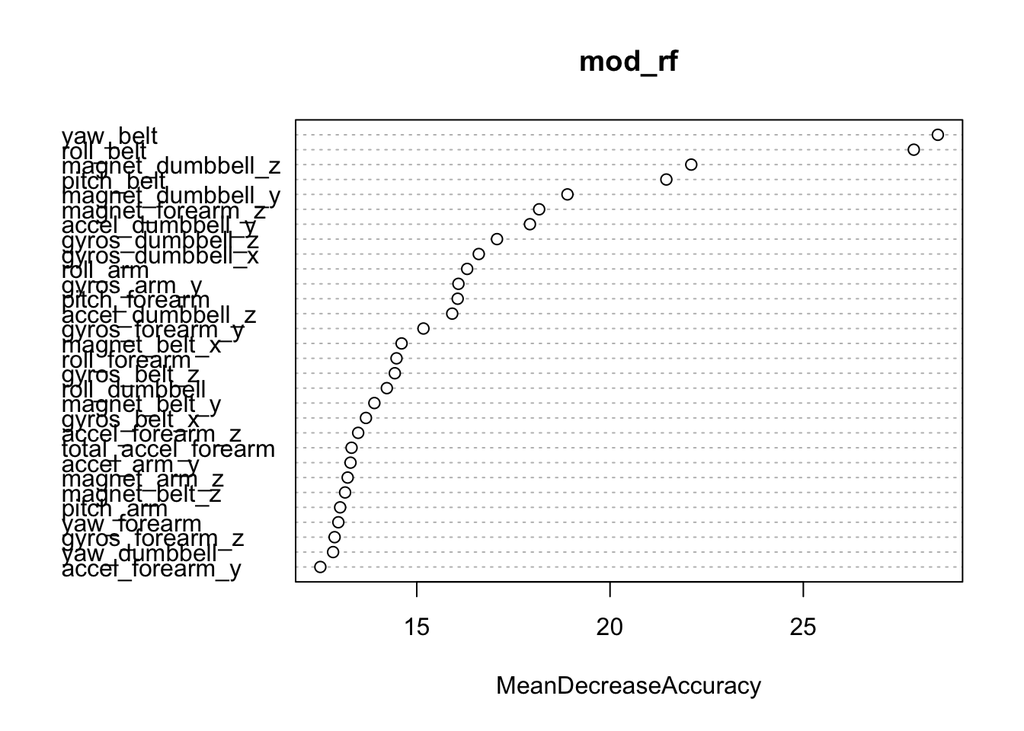

```r
mod_rf <- randomForest(classe~., data=myTrain, importance=TRUE, ntree=100)
varImpPlot(mod_rf,type=1)
```

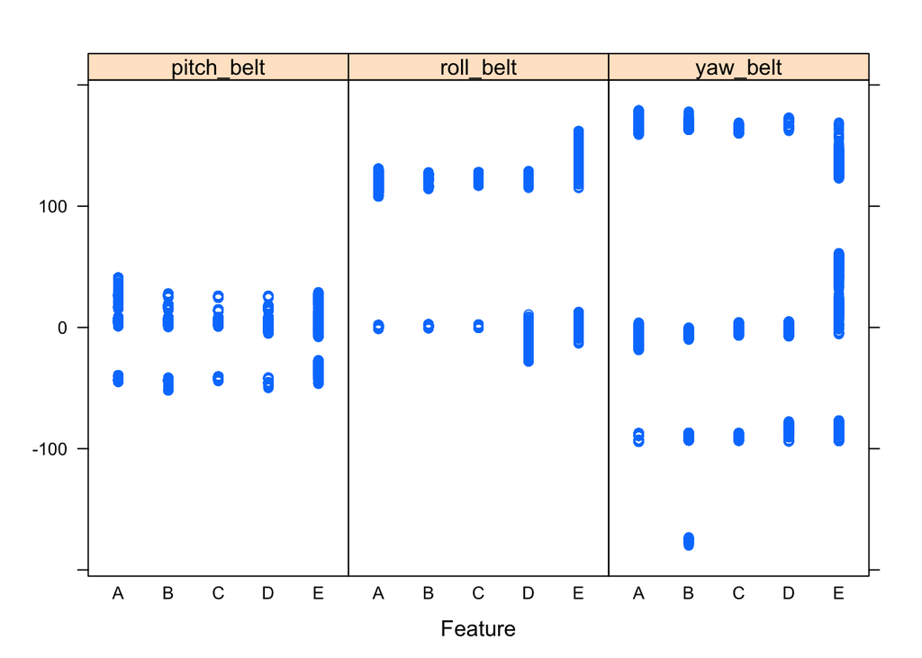

```r
featurePlot(x=myTrain[,c(1,2,3)],y=myTrain[,53])
```

### Model accuracy

The random forest model accuracy is over 99% (out of sample error rate < 1%) so no further models were tested

```r
pred <- predict(mod_rf, myTest)
confusionMatrix(pred, myTest$classe)
```

```
## Confusion Matrix and Statistics
##
##           Reference
## Prediction    A    B    C    D    E
##          A 1664    5    0    0    0
##          B    0 1119    5    0    0
##          C    0    2 1019   11    0
##          D    0    0    1  885    1
##          E    0    0    0    1 1013
##
## Overall Statistics
##
##                Accuracy : 0.9955
##                  95% CI : (0.9934, 0.997)
##     No Information Rate : 0.2906
##     P-Value [Acc > NIR] : < 2.2e-16
##
##                   Kappa : 0.9942
##  Mcnemar's Test P-Value : NA
##
## Statistics by Class:
##
##                      Class: A Class: B Class: C Class: D Class: E
## Sensitivity            1.0000   0.9938   0.9941   0.9866   0.9990
## Specificity            0.9988   0.9989   0.9972   0.9996   0.9998
## Pos Pred Value         0.9970   0.9956   0.9874   0.9977   0.9990
## Neg Pred Value         1.0000   0.9985   0.9987   0.9975   0.9998
## Prevalence             0.2906   0.1966   0.1790   0.1567   0.1771
## Detection Rate         0.2906   0.1954   0.1780   0.1546   0.1769
## Detection Prevalence   0.2915   0.1963   0.1802   0.1549   0.1771
## Balanced Accuracy      0.9994   0.9963   0.9957   0.9931   0.9994
```

### Prediction of test set of 20

Predict the output of the 20 entries in the test set

```r
predict(mod_rf, testing)
```

```
##  1  2  3  4  5  6  7  8  9 10 11 12 13 14 15 16 17 18 19 20
##  B  A  B  A  A  E  D  B  A  A  B  C  B  A  E  E  A  B  B  B
## Levels: A B C D E
```